# Lab 10: Using Sage to find information about functions

### Intercepts

```python
f(x) = (x^2 - 9)/(1 - x^2)
solve(f == 0, x)
```

```
[x == -3, x == 3]
```

Sometimes we might need to specify a range to solve the function in eg.

```python
g(x) = x + e^x
solve(g == 0, x)
```

```
[x == -e^x]
```

This is not very helpful. We can do it graphically and numerically. To graph the function, we can use the code below. We could also add an `xmin = ...`, `xmax = ...`, and `ymin = ...`, but they weren't necessary in this example.

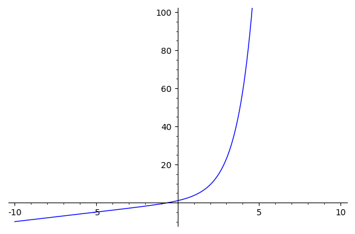

```python
g.plot(x, -10, 10).show(ymax = 100)
```

```python
find_root(g == 0, -5, 0)
```

```
-0.5671432904097838
```

We found it.

The y-intercept is the value $g(0)$ and $f(0)$ for each function:

```python
g(0)
```

```
1
```

```python
f(0)
```

```
-9
```

This tells us that the $y$-intercept of $g(x)$ is 1 and the $y$-intercept of $f(x)$ is $-9$.

### Intervals on which the function is positive, or negative

To find the intervals on which a function is positive, we can type for example:

```python
solve(f > 0, x)
```

```
[[x > -3, x < -1], [x > 1, x < 3]]
```

To find the intervals on which the function is negative, we type:

```python
solve(f < 0, x)
```

```
[[x < -3], [x > -1, x < 1], [x > 3]]
```

### Intervals on which the function is increasing, or decreasing

We can use the derivative to find the intervals on which a function is increasing, for example:

```python
solve( diff(f, x) > 0, x)
```

```
[[x < -1], [x > -1, x < 0]]
```

Likewise, we can find the intervals on which the function is decreasing by typing:

```python
solve( diff(f, x) < 0, x)
```

[output not shown]

### Critical Points

We can again use the derivative to find critical points of a function, for example:

```python
solve( diff(g, x) == 0, x)
```

```
[x == I*pi]
```

```python
#find_root(diff(g,x) == 0, 0, 1000)
#find_root(diff(g,x) == 0, -1000, 0)
#both returned no roots
```

We can use the second derivative to tell whether the critical point is a local minimum, local maximum, or inflection point:

```python
f2 = diff(f, x, 2)
f2(0)
```

```
-16
```

### Inflection Points

We can use the second derivative to find inflection points of a function, for example:

```python
solve( diff(f,x,2) == 0, x)
```

```
[x == -1/3*I*sqrt(3), x == 1/3*I*sqrt(3)]
```

Since these answers contain the imaginary number "I,", that means there is no inflection point on the real numbers

### Asympotes

You can find vertical asymptotes (if there are any) by finding the x-intercepts of the reciprocal of the function (ie. in our case by finding the x-intercepts of the function 1 - x^2):

```python
solve(1/f == 0, x)
```

```
[x == -1, x == 1]
```

This tells us that there are vertical asymptotes at x = -1, and x = 1.

To find the horizontal asymptotes (if any), we look at the limit of the function in +Infinity and -Infinity:

```python
limit(f, x =+infinity)
```

```
x |--> -1
```

```python
limit(f, x=-infinity)
```

```
x |--> -1
```

This tells us that there is a horizontal asymptote at $y=-1$ as x approaches $+\infty$, and as x approaches $-\infty$.

### Plottting Functions

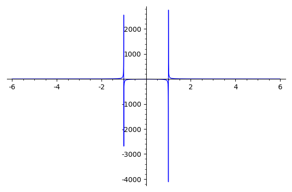

```python
plot(f, x, -6, 6)
```

Two things are wrong with this graph. First, we are showing *way* too much $y$-axis. And secondly, Sage is connecting the graph accross it's assymptote, which it ought not to do. We can fix the first part by limiting the size of the window. We can fix the second part by asking it to detect poles.

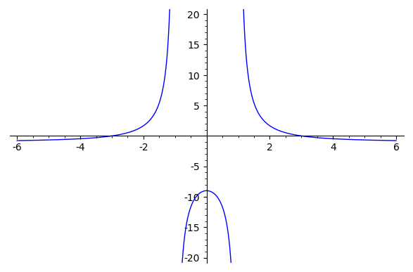

```python
plot(f, x, -6, 6, detect_poles = True).show(ymin = -20, ymax = 20)
```

# Excercises

Find the following for the functions, use Sage to find

a) $x$ & $y$ intercepts

b) Vertical Asymptotes

c) Increasing/Decreasing

d) Relative Extrema

e) Concavity

f) Inflection Points

g) Horizontal Asymptotes

h) Plot the original function

1. $g(x)=x^3 - 7x + 6$
1. $h(x)=\frac{x^5}{20}-\frac{3 x^4}{4}-12 x^2 + \frac{11}{x-1}$
1. $f(x)= 7\arctan(x+1)-\ln(x^2+2x+2)$